# Homework 12 | Unsupervised clustering

Golub leukemia gene-expression data · 38 samples × 3,051 genes

## Approach and method selection

After checking for missing values (none), I standardized each gene across samples and used the first five principal components (41.8% of standardized-feature variance). I compared K-means, Ward hierarchical, and nearest-neighbor spectral clustering over 2–5 clusters, using silhouette separation, cluster sizes, and avoidance of singletons. **K-means with four clusters** was selected because it had the highest silhouette among solutions without singleton clusters (k = 5 scored slightly higher but isolates one sample) and is easy to interpret; the leukemia labels were excluded from fitting and selection.

## Selected clustering: K-means (k = 4)

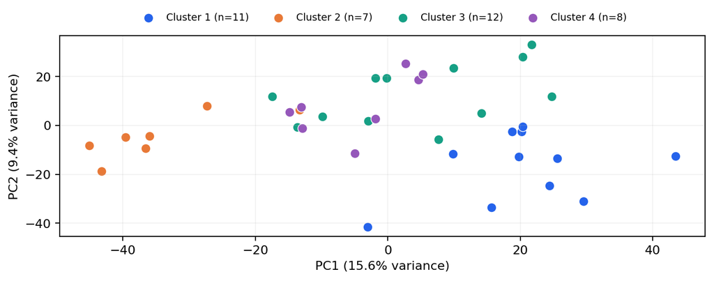

Figure: PCA projection onto the first two components. K-means used five PCs, so distances in this 2-D view do not fully represent the fitted space.

## Cluster composition

| Selected group | ALL | AML | Total |
| --- | --- | --- | --- |
| Cluster 1 | 1 | 10 | 11 |
| Cluster 2 | 7 | 0 | 7 |
| Cluster 3 | 11 | 1 | 12 |
| Cluster 4 | 8 | 0 | 8 |

Known diagnosis labels are shown for post hoc interpretation only.

## Interpretation and limitations

The selected solution has a silhouette score of **0.292** (on the five PCs), which indicates only weak-to-moderate structure. Cluster 1 holds 10 of the 11 AML samples plus one ALL sample; clusters 2–4 hold 26 of the 27 ALL samples plus one AML sample. The expression-based groups therefore largely recover the AML/ALL split while dividing ALL into three groups. Diagnoses were used only after clustering, so this shows association, not validation.

These clusters should not be treated as established leukemia subtypes: the sample is small relative to 3,051 features, and results depend on standardization, PCA retention, and the chosen cluster count, and K-means assignments shifted under some random seeds (adjusted Rand index 0.74–1.0 across 10 seeds). The three ALL groups are not shown to be real subtypes. A two-dimensional plot can conceal separation in other components.

Source: Golub data, Bioconductor multtest 2.68.0; 27 ALL and 11 AML samples. Reproducible settings: sklearn StandardScaler, PCA(n_components=5), KMeans(n_clusters=4, n_init=50, random_state=42).

# Appendix | Complete SKILL.md

Standalone skill definition (2944 bytes; below 5,000-byte limit). Invoke explicitly as `unsupervised-cluster-report`.

```
---
name: unsupervised-cluster-report
description: Explicitly invoked workflow for comparing clustering algorithms and producing a one-page, evidence-based clustering report.
---

# Invocation
Run only when explicitly invoked by name. Receive the dataset path, observation unit, feature columns, identifier columns, optional external labels, and output path as invocation inputs. Never assume a particular dataset.

# Workflow
1. Audit row count, feature types, missingness, duplicates, and scale. Exclude IDs and external outcome/class labels from all fitting, tuning, and method selection. Explain missing-value handling. Apply defensible transformations and feature scaling fitted on the data; avoid leakage from external labels.
2. If dimension reduction is useful, fit PCA on the feature matrix (not on labels), record explained variance, and compare a small set of defensible retained dimensions. An embedding is not a clustering method. Keep a consistent feature representation for comparisons, or explicitly disclose differences.
3. Try at least three actual algorithms: K-means, agglomerative hierarchical clustering (e.g., Ward), and spectral clustering. Explore plausible numbers of clusters (typically 2–5, restricted by sample size). Tune relevant parameters such as linkage, neighborhood size, and initialization; fix random seeds.
4. Select using only unsupervised evidence: silhouette/separation, sensible cluster sizes, reproducibility under seeds or resampling, robustness to preprocessing, and interpretability. Do not maximize an external-label agreement score. Avoid trivial singleton-driven solutions and acknowledge competing criteria. Record why the final choice beats alternatives.
5. Refit the chosen configuration. Summarize its cluster counts and structure. Use a clear, labeled 2-D PCA scatterplot colored by the selected cluster assignments; explain that the plot is a projection and that clustering may have used more dimensions. Optionally interpret the selected clusters using held-out external labels only after selection; distinguish association from validation or causation.
6. Audit consistency of totals, figure labels, metrics, and narrative. State limitations including small samples, high dimension, scaling choices, and potential instability.

# Output contract
Generate an analysis report limited to **one printed page total**, including every title, sentence, figure, and table. Present clustering results from **only the single selected method**. Other methods may be named briefly to justify selection, but show no assignments, scores, tables, or figures for those alternatives. Include a concise method/selection rationale, one informative figure, key selected-method evidence, interpretation, and limitations. Put the full skill definition in an appendix **after** the one-page report; the appendix is exempt from the page limit. Supply both the report and this complete SKILL.md as requested.
```